# Social Monkey Data Analysis and Figure Creation

Pearce et al.

2024-03-26

This document, in conjunction with the **DataAnalaysisFunctions.R** file, comprises the full scripting for our data analysis procedures (post-sample sequencing).

**Installation Requirements:**

- R language, minimum version 4.3.2 (via https://cran.r-project.org/)
- The following R packages via `install.packages()`:
  - languageserver, rmarkdown, httpgd
- The Bioconductor package manager `BiocManager` (via https://cran.r-project.org/web/packages/BiocManager/vignettes/BiocManager.html)
- The following Bioconductor packages via `BiocManager::install()`:
  - tidyverse, vegan, magrittr, glue, ggpubr, svglite, RColorBrewer, phyloseq, microbiomeMarker, rstatix
- The `pairwiseAdonis` R package (via GitHub at https://github.com/pmartinezarbizu/pairwiseAdonis)

```r
# Set seed to ensure consistent random number results
set.seed(42)

# Retrieve source code for data analysis functions
source("DataAnalysisFunctions.R")
```

Load in required packages. If needed, install packages using `install.packages()`

```r
library(tidyverse)
library(vegan)
library(phyloseq)
library(microbiomeMarker)
library(magrittr)
library(glue)
library(ggpubr)
library(svglite)
library(RColorBrewer)
library(rstatix)
library(pairwiseAdonis)
```

### Prepare Data for Analysis and Figure Creation

Load in the meta data files

```r
metadata <- "MetaDataFiles/metadata.RDS" %>% glue() %>% readRDS()
ps <- "MetaDataFiles/ps.RDP.tree.RDS" %>% glue() %>% readRDS()
# 'ps' is phyloseq
```

Modify the meta data files:

```r
ps %<>% subset_samples(Sex == "Male") %>%  # remove non-male samples
  subset_samples(!(SampleNum %in% c("Quinn1_S11", "Eli6_S54"))) %>% # removing low read-count samples. Explanation for removal of these samples is discussed in the main text.
  rarefy_even_depth(sample.size = 25000) # Rarefying samples to 25,000 reads

# Removing non-relevant columns
sample_data(ps)[, c("X.NAME", "Age", "Trace", "Sex")] <- NULL

# Making the 'Timepoint' column into a categorical factor
sample_data(ps)$Timepoint %<>% as.factor

# Making a 'Diet' column to indicate diet condition at each timepoint
sample_data(ps)$Diet <- ps %>%
  sample_data() %>%
  as("data.frame") %>%
  mutate(Diet = case_when(
    Timepoint %in% "1" ~ "Uncontrolled",
    Timepoint %in% c("2", "3", "4", "6") ~ "Controlled"
    )) %>%
    pull(Diet)

# Important Note: Our 'RSL' timepoint discussed in the main text is labelled 'T6' throughout this script for ease
```

Add in alpha diversity measures:

```r
measures <- c("Observed", "Chao1", "Shannon", "Fisher")
for (measure in measures) {
    sample_data(ps)[[measure]] <- estimate_richness(ps, measures = measure)[, 1]
}
```

Create a tibble and add in abundance values

```r
melt <- ps %>%
    tax_glom(taxrank = "Family") %>%
    transform_sample_counts(function(otu) otu / sum(otu)) %>%
    psmelt() %>%
    mutate(Family = ifelse(Abundance < 0.05, "Other", Family)) %>%
    filter(Abundance != 0) %>%
    mutate(Family = gsub("_1$", "", Family)) %>%
    mutate(Family = reorder(Family, ifelse(Family == "Other", 1, 0)))
View(melt)
```

The data has been prepped. We can now produce figures and conduct our statistical analyses.

### Figure Creation and Data Analysis

*Note that Figure 1A, the study design, was created using Adobe Illustrator.*

We began by inspecting the diversity of our samples with plots of relative abundance. In the main text we report relative abundance across timepoints (Fig. 1B) and report relative abundance by animal in our supplemental materials (Fig. S1).

##### Figure 1B: Relative Bacterial Abundance Across Timepoints (by Bacteria)

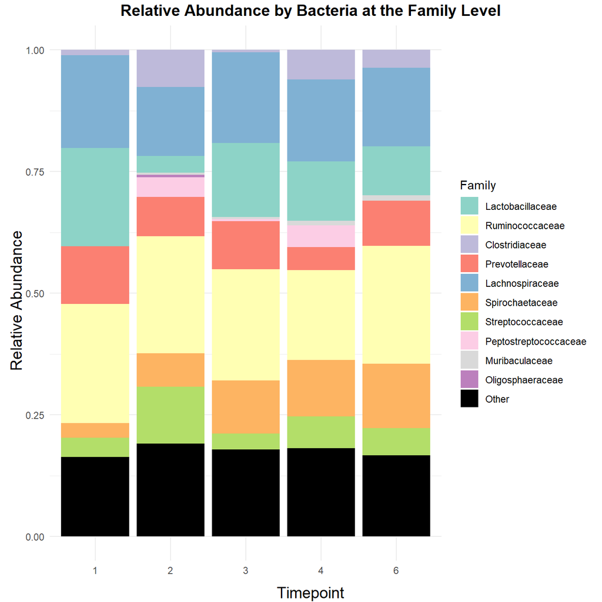

```r
n_taxa = melt %>% select(Family) %>% unique %>% nrow
rel_abund_palette <- c(brewer.pal(n = n_taxa - 1, name = "Set3"), "#000000")
relative_abundance_bacteria <- plot_bar_graph_bacteria(melt, rel_abund_palette) %>%
  annotate_figure(
    top = text_grob("Relative Abundance by Bacteria at the Family Level",
      face = "bold",
      size = 14
    ),
    bottom = text_grob("Timepoint", size = 14),
    left = text_grob("Relative Abundance", size = 14, rot = 90, vjust = 1)
  ) %T>% plot
```

##### Supplementary Figure 1 (S1): Relative Bacterial Abundance Across Timepoints (by Animal)

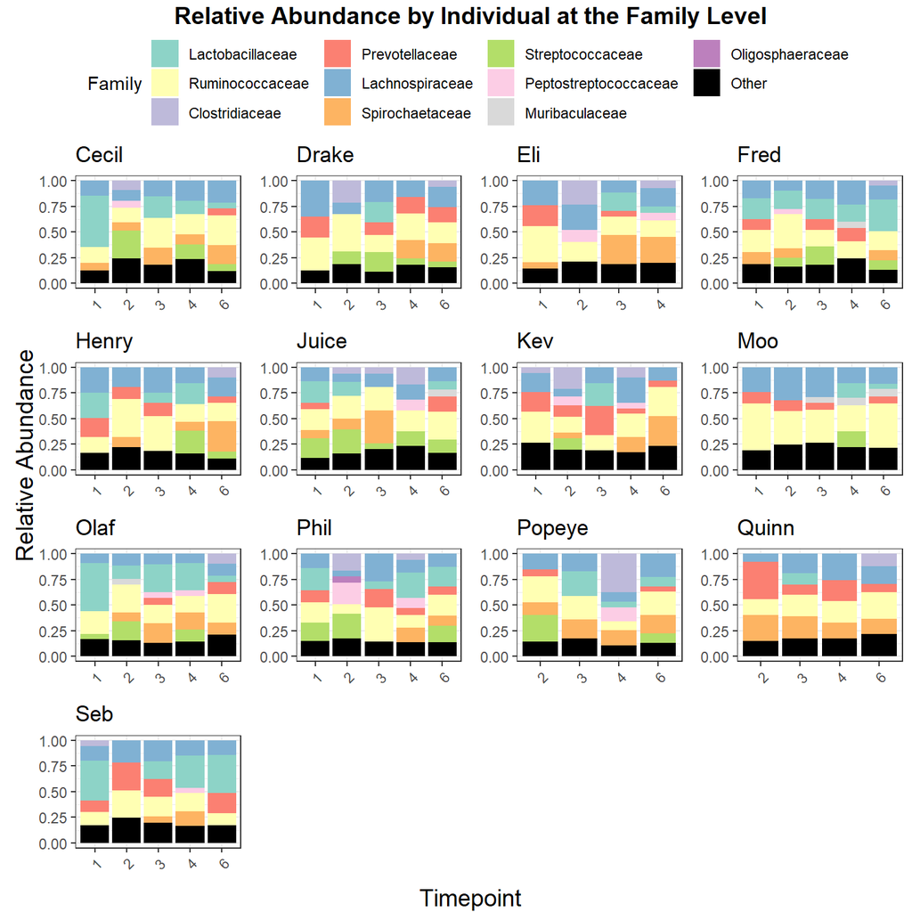

```r
n_taxa = melt %>% select(Family) %>% unique %>% nrow
rel_abund_palette <- c(brewer.pal(n = n_taxa - 1, name = "Set3"), "#000000")

graph_rel_abund <- ggarrange(
    plotlist = unique(meta(ps)[["Name"]]) %>%
        map(plot_bar_graph, palette = rel_abund_palette), ncol = 4, nrow = 4, common.legend = TRUE) %>%
    annotate_figure(
        top = text_grob("Relative Abundance by Individual at the Family Level", face = "bold", size = 14),
        bottom = text_grob("Timepoint", size = 14),
        left = text_grob("Relative Abundance", size = 14, rot = 90, vjust = 1)
     ) %T>% plot
```

#### Figure 2: Changes in diet result in changes in gut microbiota composition

Next, we look at the effect of diet on gut microbiota composition. To do this we compare timepoints 1(T1) and 2(T2), which is uncontrolled diet and controlled diet, respectively.

We began by assessing alpha diversity with a non-parametric Wilcoxon signed-rank test (comparing T1 and T2) and visualizing with a boxplot (Fig. 2A). Then we conducted a PERMANOVA with T1 and T2 data, and visualized this data with NMDS plots (Fig. 2B). Finally, we used the linear discriminant analysis effect size (LEfSe) method to identify bacterial families driving our diet effect and also visualized this data via boxplot (Fig. 2C).

Reported in the main text for all analyses are the **family level results and those obtained with weighted UniFrace distances**. Genus level results and results obtained with Bray-Curtis distances are reported in the supplementary files.

##### Figure 2A: Chao1 Alpha Diversity Across Timepoints

*Note that we assess alpha diversity with four different metrics, but only discuss one metric, **Chao1**, in the main text. The additional measures of alpha diversity are presented in the supplmental materials.*

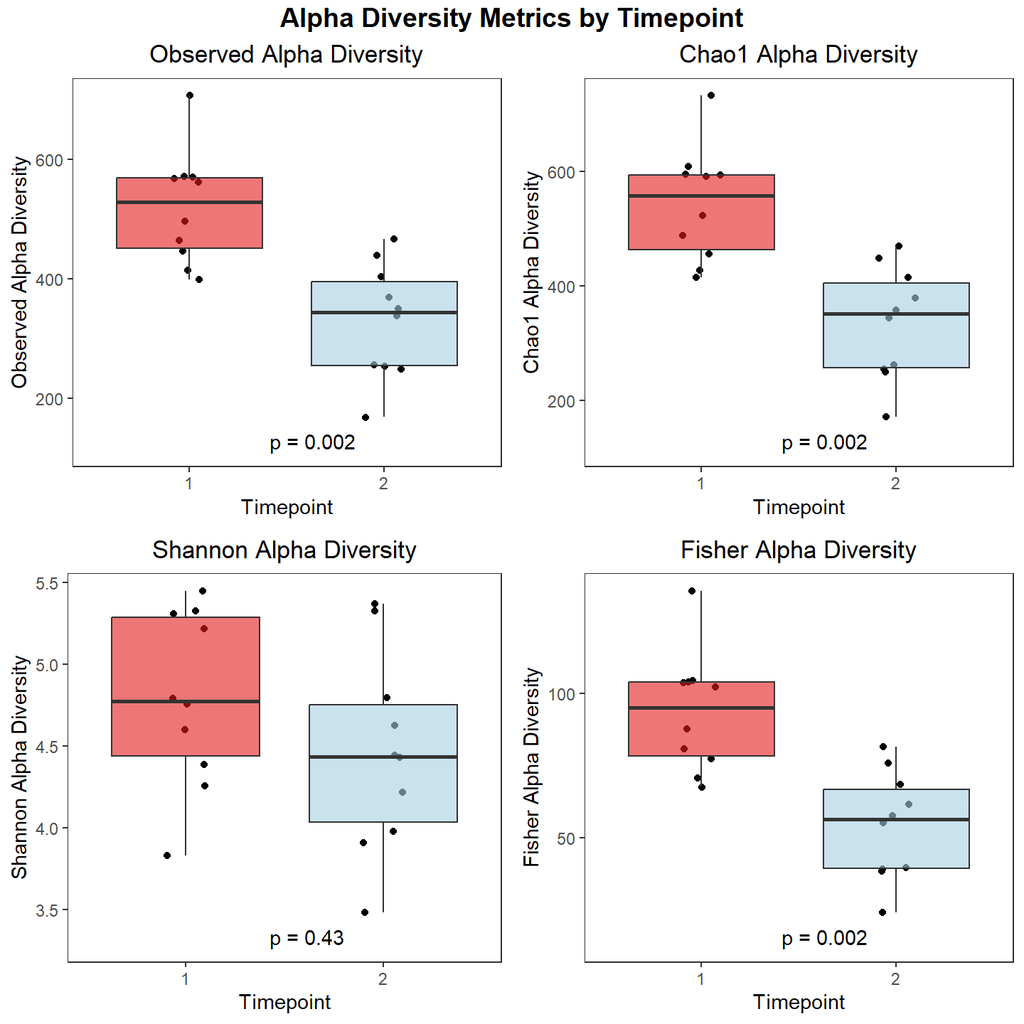

```r
# Alpha diversity for diet manipulation, comparing T1 and T2.
group <- "Timepoint"
measures <- c("Observed", "Chao1", "Shannon", "Fisher")
diet_palette <- c("#E31A1C","#A6CEE3")

# clean data of excluded samples. Sample exclusion is dicsussed in the main text
clean_ps <- ps %>%
    subset_samples(Timepoint %in% c(1,2) & !(Name %in% c("Quinn", "Popeye", "Eli"))) %>%
    meta()

diet_alpha_diversity <- clean_ps %>%
    aggregate_plot_alpha_diet(group, measures, diet_palette) %T>% plot
```

```r
# Statistical testing of alpha diversity - Wilcoxon signed-rank tests
wilcox_observed <- clean_ps %>%
    wilcox_test (formula = Observed ~ Timepoint, paired = TRUE)

wilcox_chao1 <- clean_ps %>%
    wilcox_test (formula = Chao1 ~ Timepoint, paired = TRUE)

wilcox_shannon <- clean_ps %>%
    wilcox_test (formula = Shannon ~ Timepoint, paired = TRUE)

wilcox_fisher <- clean_ps %>%
    wilcox_test (formula = Fisher ~ Timepoint, paired = TRUE)

 # Note: Significance bars were added to graphs afterwards using Adobe Illustrator
```

From these plots and anlyses, specifically **Chao1**, we see that our alpha diversity does differ significantly between T1 and T2. This indicates that the change in diet from uncontrolled to controlled significantly changed the species richness in the gut microbiota.

Next we assess beta diversity.

##### Figure 2B: NMDS plots for T1 and T2 - Diet Effect

*Note that the genus level results and the results obtained with Bray-curtis distances are presented in the supplemental materials.*

```
## *** Best solution repeated 1 times
## Permutation test for adonis under reduced model
## Terms added sequentially (first to last)
## Plots: (meta(ps_diet))$Name, plot permutation: free
## Permutation: free
## Number of permutations: 1000
##
## adonis2(formula = distance(ps_diet_modified, method) ~ Timepoint, data = meta(ps_diet_modified), permutations = perms_diet)
##           Df SumOfSqs      R2      F   Pr(>F)
## Timepoint  1  0.42787 0.19177 4.7454 0.001998 **
## Residual  20  1.80332 0.80823
## Total     21  2.23119 1.00000
## ---
## Signif. codes:  0 '***' 0.001 '**' 0.01 '*' 0.05 '.' 0.1 ' ' 1
```

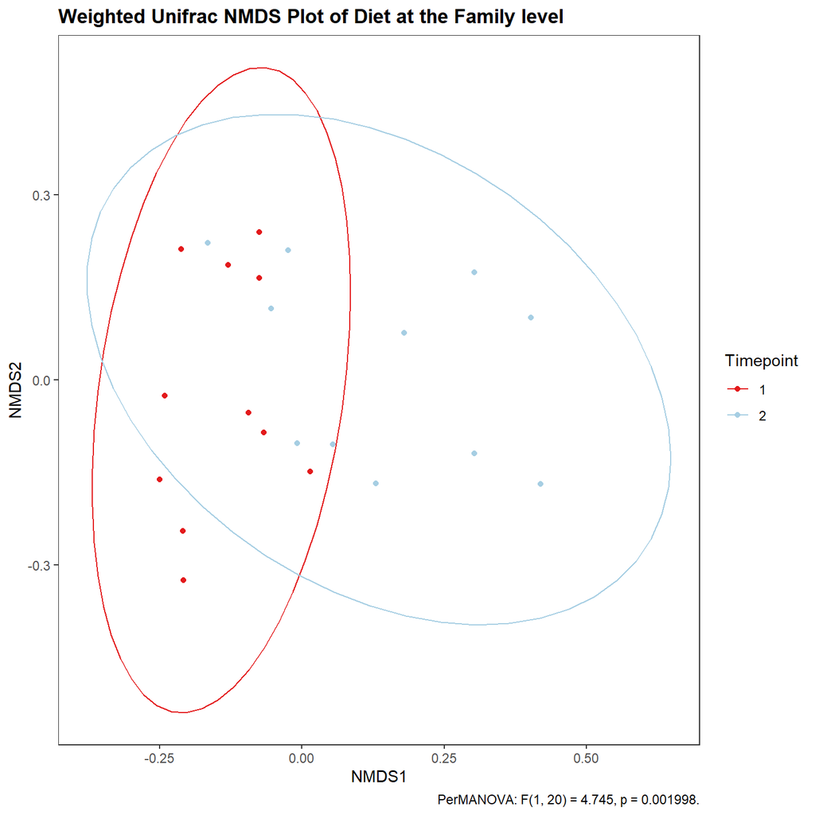

```r
# Removing two animals due to no data being available. Smaple exlcusion is dicsused in the main text.
ps_diet <- ps %>% subset_samples(!(Name %in% c("Quinn", "Popeye"))) %>% subset_samples(!(Timepoint %in% c(3, 4, 6)))

# Ordination function for the diet effect plots
ordination_plot <- function(method, rank) {
    suppressWarnings({
        ps_diet_modified <- ps_diet %>% tax_glom(rank)
        ord_diet <- ordinate(ps_diet_modified, method = "NMDS", distance = method)

        perms_diet <- how(plots = Plots(strata = (meta(ps_diet))$Name, type = "free"), nperm = 1000)
        perm <- adonis2(distance(ps_diet_modified, method) ~ Timepoint, data = meta(ps_diet_modified), permutations = perms_diet)
        print(perm)

        p.value = format(perm$`Pr(>F)`, digits = 4)
        df = perm$Df
        F.stat = format(perm$F, digits = 4)
    })

    if (method == "wunifrac") method <- "Weighted Unifrac"
    else if (method == "bray") method <- "Bray-Curtis"

    graph <- plot_ordination(physeq = ps_diet_modified, ordination = ord_diet) +
        geom_point(aes(color = Timepoint)) +
        stat_ellipse(aes(color = Timepoint)) +
        theme_bw() +
        theme(plot.title = element_text(face = "bold"), panel.grid = element_blank()) +
        labs(
          caption = str_glue("PerMANOVA: F({df[1]}, {df[2]}) = {F.stat}, p = {p.value}."),
          title = glue("{method} NMDS Plot of Diet at the {rank} level"),
          color = str_glue("Timepoint")
        ) +
        scale_color_manual(values = c("#E31A1C", "#A6CEE3"))
     return(graph)
}

# Run the analysis and print the graphs for family and genus Levels
ordination_graph_diet_wunifrac_family <- ordination_plot("wunifrac", "Family") %T>% plot
```

```
## *** Best solution repeated 1 times
## Permutation test for adonis under reduced model
## Terms added sequentially (first to last)
## Plots: (meta(ps_diet))$Name, plot permutation: free
## Permutation: free
## Number of permutations: 1000
##
## adonis2(formula = distance(ps_diet_modified, method) ~ Timepoint, data = meta(ps_diet_modified), permutations = perms_diet)
##           Df SumOfSqs      R2      F   Pr(>F)
## Timepoint  1   0.2044 0.16574 3.9732 0.001998 **
## Residual  20   1.0289 0.83426
## Total     21   1.2333 1.00000
## ---
## Signif. codes:  0 '***' 0.001 '**' 0.01 '*' 0.05 '.' 0.1 ' ' 1
```

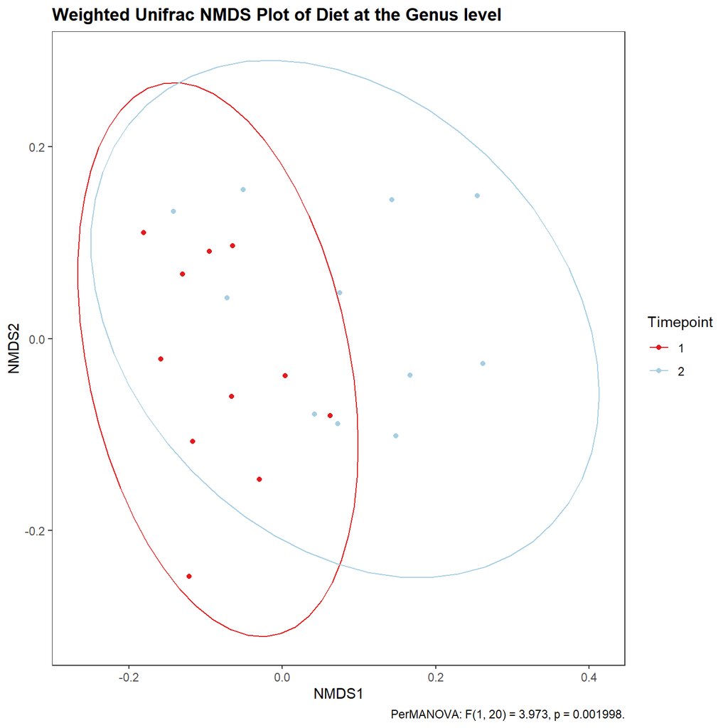

```r
ordination_graph_diet_wunifrac_genus <- ordination_plot("wunifrac", "Genus") %T>% plot
```

```
## Square root transformation
## Wisconsin double standardization
## *** Best solution repeated 2 times
## Permutation test for adonis under reduced model
## Terms added sequentially (first to last)
## Plots: (meta(ps_diet))$Name, plot permutation: free
## Permutation: free
## Number of permutations: 1000
##
## adonis2(formula = distance(ps_diet_modified, method) ~ Timepoint, data = meta(ps_diet_modified), permutations = perms_diet)
##           Df SumOfSqs     R2      F   Pr(>F)
## Timepoint  1  0.39031 0.1793 4.3696 0.001998 **
## Residual  20  1.78647 0.8207
## Total     21  2.17678 1.0000
## ---
## Signif. codes:  0 '***' 0.001 '**' 0.01 '*' 0.05 '.' 0.1 ' ' 1
```

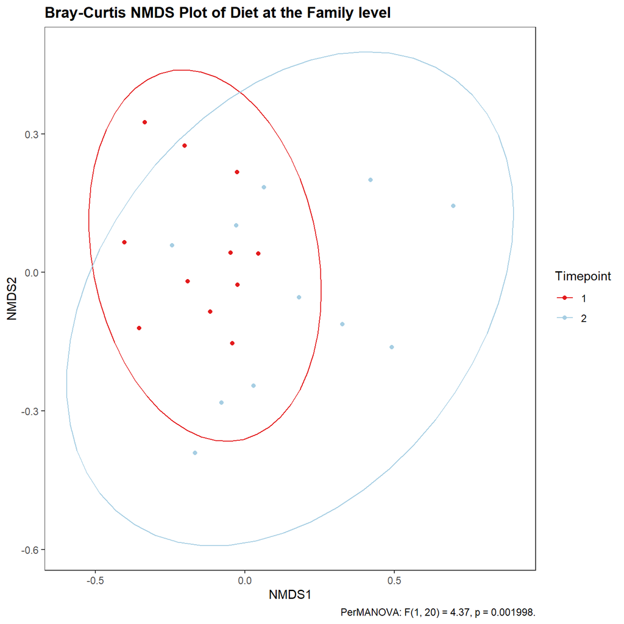

```r
ordination_graph_diet_bray_family <- ordination_plot("bray", "Family") %T>% plot
```

```
## Square root transformation
## Wisconsin double standardization
## *** Best solution repeated 7 times
## Permutation test for adonis under reduced model
## Terms added sequentially (first to last)
## Plots: (meta(ps_diet))$Name, plot permutation: free
## Permutation: free
## Number of permutations: 1000
##
## adonis2(formula = distance(ps_diet_modified, method) ~ Timepoint, data = meta(ps_diet_modified), permutations = perms_diet)
##           Df SumOfSqs      R2      F   Pr(>F)
## Timepoint  1   0.5867 0.15586 3.6927 0.000999 ***
## Residual  20   3.1779 0.84414
## Total     21   3.7646 1.00000
## ---
## Signif. codes:  0 '***' 0.001 '**' 0.01 '*' 0.05 '.' 0.1 ' ' 1
```

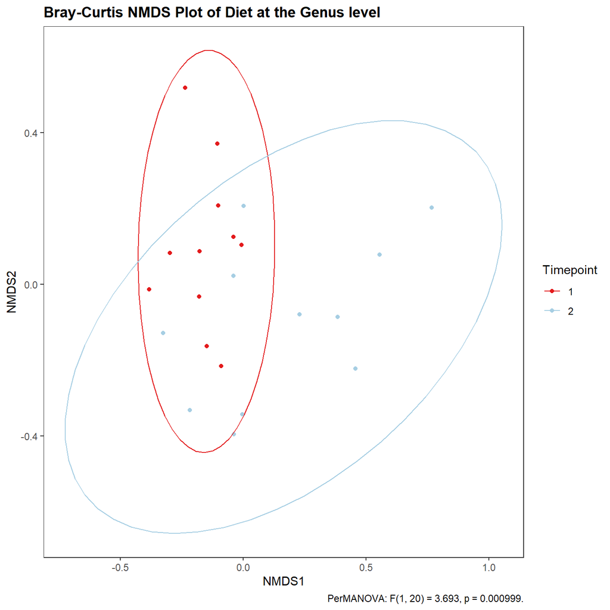

```r
ordination_graph_diet_bray_genus <- ordination_plot("bray", "Genus") %T>% plot
```

Looking at our NMDS plots, specifically the family level results calculated with weighted UniFrac distances, we see that our PERMANOVA analysis revealed a significant effect of diet on gut microbiota composition.

To follow-up this significant PERMANOVA result, we conducted an LEfSe analysis to identify bacteria that are driving the significant diet effect.

##### Figure 2C: LEfSe Tests & Plots for the Diet Effect

*Note that the genus level analysis is presented in the supplmental materials and is not discussed in the main text.*

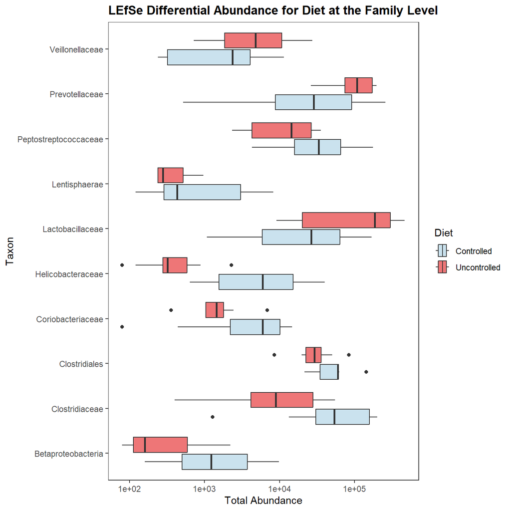

```r
# Differential Bacterial Abundance for the Diet Effect: Timepoints 1 and 2

#----- FAMILY LEVEL -----#

# Run LEfSe analysis
lefse_diet_family <- ps_diet %>%
run_lefse(
  group = "Diet",
  taxa_rank = "Family",
  wilcoxon_cutoff = 0.05,
  kw_cutoff = 0.05,
  lda_cutoff = 3
)

# View results
lefse_diet_family_RESULTS <- marker_table(lefse_diet_family) %>% as_tibble %>% mutate(Test = "Timepoint")
View(lefse_diet_family_RESULTS)

# Graph results
graph_relAbund_diet_family <- lefse_diet_family %>%
plot_abundance(group = "Diet") +
scale_x_continuous(trans = "log10") +
labs(
  x = "Total Abundance",
  y = "Taxon",
  title = "LEfSe Differential Abundance for Diet at the Family Level"
) +
theme(plot.title = element_text(face="bold"), panel.grid = element_blank()) +
scale_y_discrete(labels = function(x) gsub("_.*", "", x)) +
scale_fill_manual(values = alpha(c("#A6CEE3", "#E31A1C"), 0.6))
plot(graph_relAbund_diet_family)
```

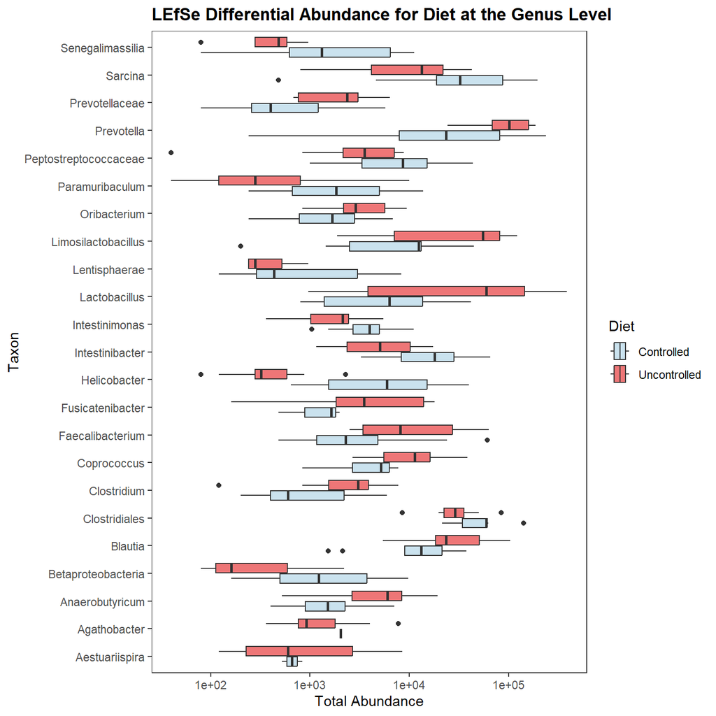

```r
#----- GENUS LEVEL -----#

# Run LEfSe analysis
lefse_diet_genus <- ps_diet %>%
run_lefse(
  group = "Diet",
  taxa_rank = "Genus",
  wilcoxon_cutoff = 0.05,
  kw_cutoff = 0.05,
  lda_cutoff = 3
)

# View results
lefse_diet_genus_RESULTS <- marker_table(lefse_diet_genus) %>% as_tibble %>% mutate(Test = "Timepoint")
View(lefse_diet_genus_RESULTS)

# Graph results
graph_relAbund_diet_genus <- lefse_diet_genus %>%
plot_abundance(group = "Diet") +
scale_x_continuous(trans = "log10") +
labs(
  x = "Total Abundance",
  y = "Taxon",
  title = "LEfSe Differential Abundance for Diet at the Genus Level"
) +
theme(plot.title = element_text(face="bold"), panel.grid = element_blank()) +
scale_y_discrete(labels = function(x) gsub("_.*", "", x)) +
scale_fill_manual(values = alpha(c("#A6CEE3", "#E31A1C"), 0.6))
plot(graph_relAbund_diet_genus)
```

#### Figure 3: Changes in social living conditions result in changes in gut microbiota composition

We next move onto the effect of social living condition on gut microbiota composition. Once again, we assess alpha and beta diversity measures.

We began by assessing alpha diversity with a non-parametric Friedman test (comparing timepoints 2, 3, 4, and RSL(6)) and visualizing with a boxplot (Fig. 3A). Then we conducted a PERMANOVA with T2, T3, T4, and RSL data and visualized this data with NMDS plots (Fig. 3B). Finally, we finished with an LEfSe analysis to identify bacterial families driving our social living effect. These data are also visualized via boxplot (Fig. 3C).

##### Figure 3A: Alpha Diversity Plot for T2, T3, T4, & RSL(T6) - Social Living Effect

*Note that we assess alpha diversity with four different metrics, but only discuss one metric, **Chao1**, in the main paper text.* *The additional measures of alpha diversity are presented in the supplmental materials.*

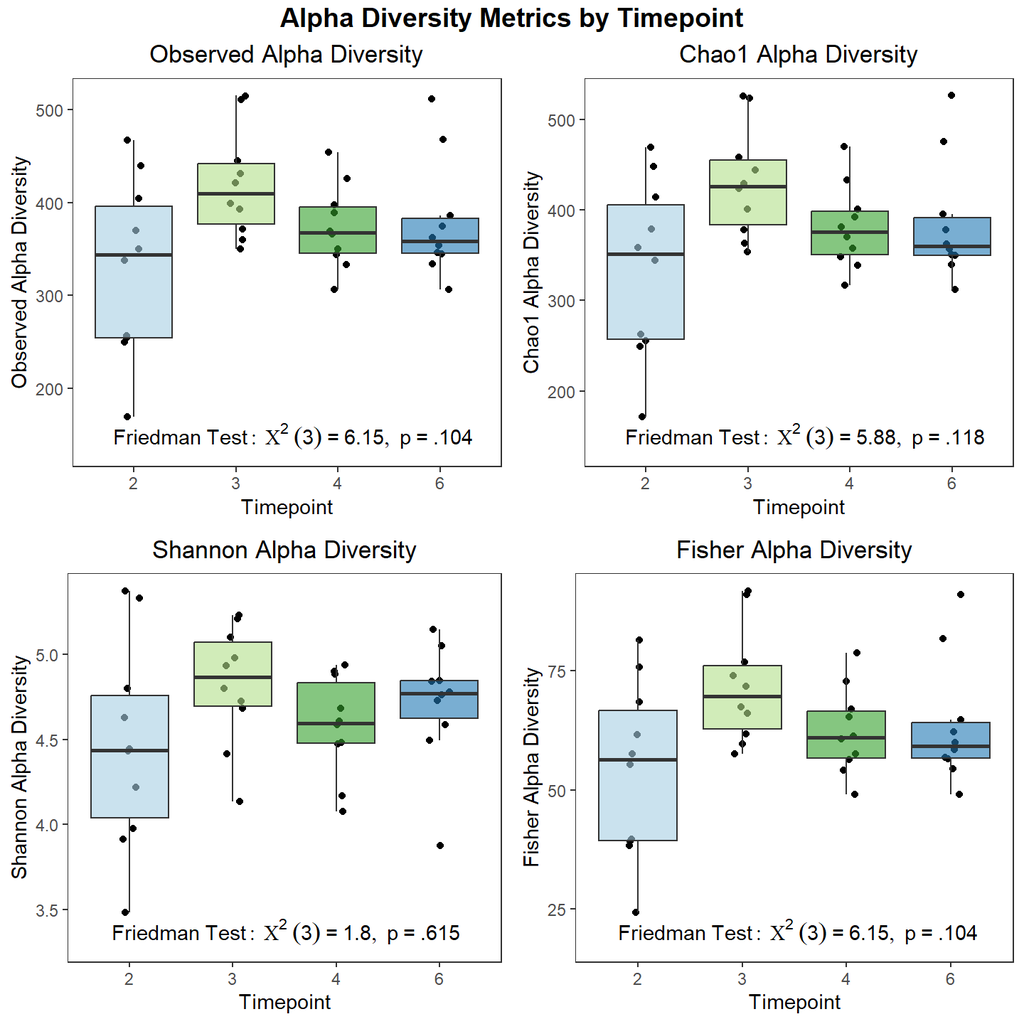

```r
# Alpha diversity for social manipulation (T2, T3, T4, RSL)
group <- "Timepoint"
measures <- c("Observed", "Chao1", "Shannon", "Fisher")
social_palette <- c("#A6CEE3", "#B2DF8A", "#33A02C", "#1F78B4")

social_alpha_diversity <- ps %>%
    subset_samples(Timepoint %in% c(2,3,4,6) & !(Name %in% c("Quinn", "Popeye", "Eli"))) %>%
    meta() %>%
    aggregate_plot_alpha_social(group, measures, social_palette) %T>% plot
```

From these plots and anlyses, specifically **Chao1**, we see that our alpha diversity did not differ significantly between T2, T3, T4, and RSL. This indicates that the change in social living conditions, from single, to social, and back to single, did not significantly change the species richness in the gut microbiota. This is not surprising as with out our diet control we would not expect to see new bacteria introduced to the animals’ gut microbiota.

Next we assess beta diversity.

##### Figure 3B: NMDS plots for T2, T3, T4, & RSL(T6) - Social Living Effect

*Note that the genus level analysis and the results obtained with Bray-curtis distances are presented in the supplmental materials and are not discussed in the paper.*

```
## *** Best solution repeated 2 times
```

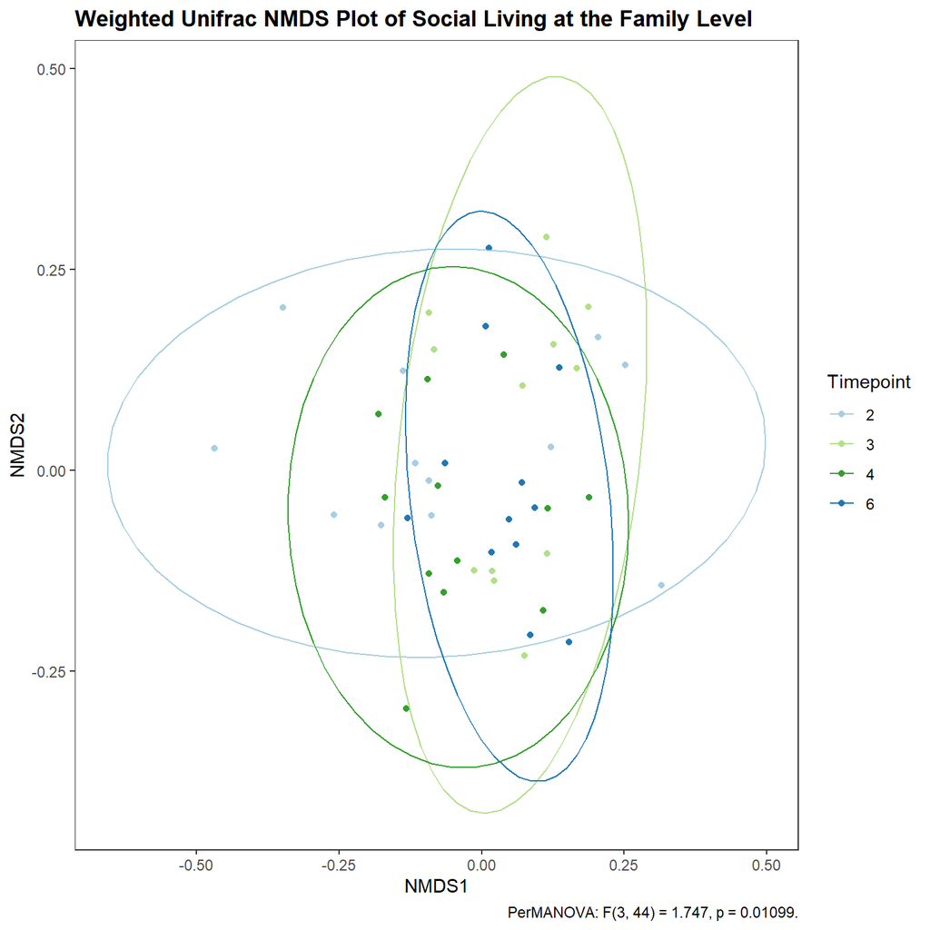

```r
# Removing one animal due to no data collection for them at the RSL timepoint. Sample exclusion is discussed in the main text
ps_social <- ps %>% subset_samples(!(Name %in% "Eli"))

# Palette for analyses of the social effect
social_palette <- c("#A6CEE3", "#B2DF8A", "#33A02C", "#1F78B4")

# Ordination function for the effect of social living plots
ordination_plot2 <- function(method, rank) {
    suppressWarnings({
        ps_social_modified <- ps_social %>% subset_samples(!(Timepoint %in% c("1"))) %>% tax_glom(rank)
        ord_social <- ordinate(ps_social_modified, method = "NMDS", distance = method)

        perms_social <- how(blocks = (meta(ps_social_modified))$Name, nperm = 1000)
        perm <- adonis2(distance(ps_social_modified, method) ~ Timepoint, data = meta(ps_social_modified), permutations = perms_social)

        p.value = format(perm$`Pr(>F)`, digits = 4)
        df = perm$Df
        F.stat = format(perm$F, digits = 4)
    })

  if (method == "wunifrac")method <- "Weighted Unifrac"
  else if (method == "bray") method <- "Bray-Curtis"

    graph <- plot_ordination(physeq = ps_social_modified, ordination = ord_social) +
      geom_point(aes(color = Timepoint)) +
      stat_ellipse(aes(color = Timepoint)) +
      theme_bw() +
      theme(plot.title = element_text(face = "bold"), panel.grid = element_blank()) +
      labs(
            caption = str_glue("PerMANOVA: F({df[1]}, {df[2]}) = {F.stat}, p = {p.value}."),
            title = str_glue("{method} NMDS Plot of Social Living at the {rank} Level"),
            color = str_glue("Timepoint")
      ) +
      scale_color_manual(values = social_palette)
    return(graph)
}

# Run the analysis and print the graphs for family and genus Levels
ordination_graph_social_wunifrac_family <- ordination_plot2("wunifrac", "Family") %T>% plot
```

```
## *** Best solution repeated 16 times
```

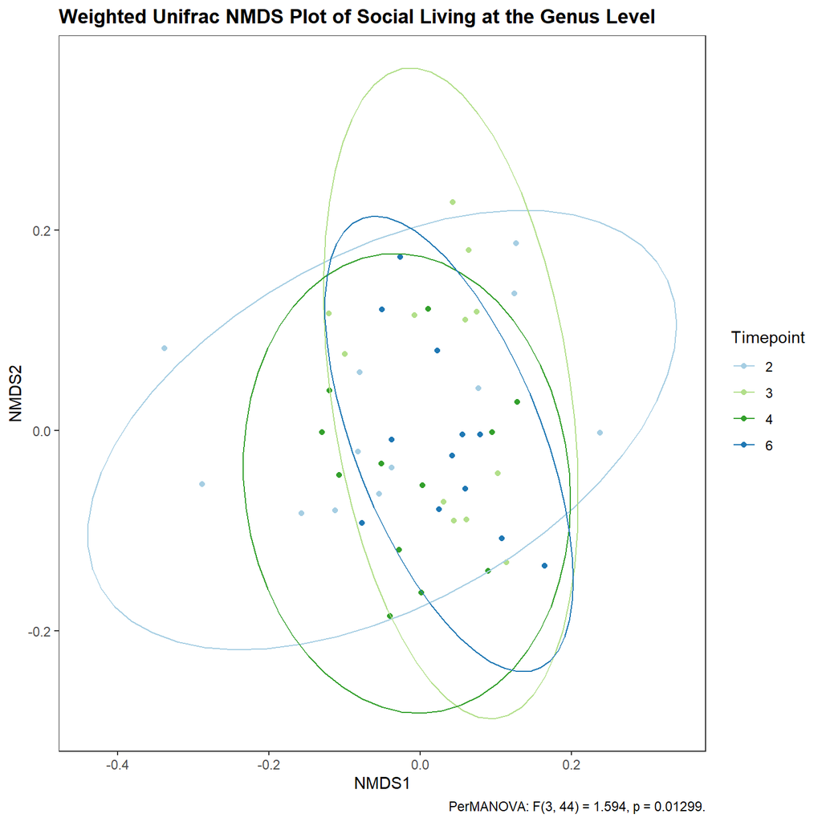

```r
ordination_graph_social_wunifrac_genus <- ordination_plot2("wunifrac", "Genus") %T>% plot
```

```
## Square root transformation
## Wisconsin double standardization
## *** Best solution was not repeated -- monoMDS stopping criteria:
##      1: no. of iterations >= maxit
##     19: stress ratio > sratmax
```

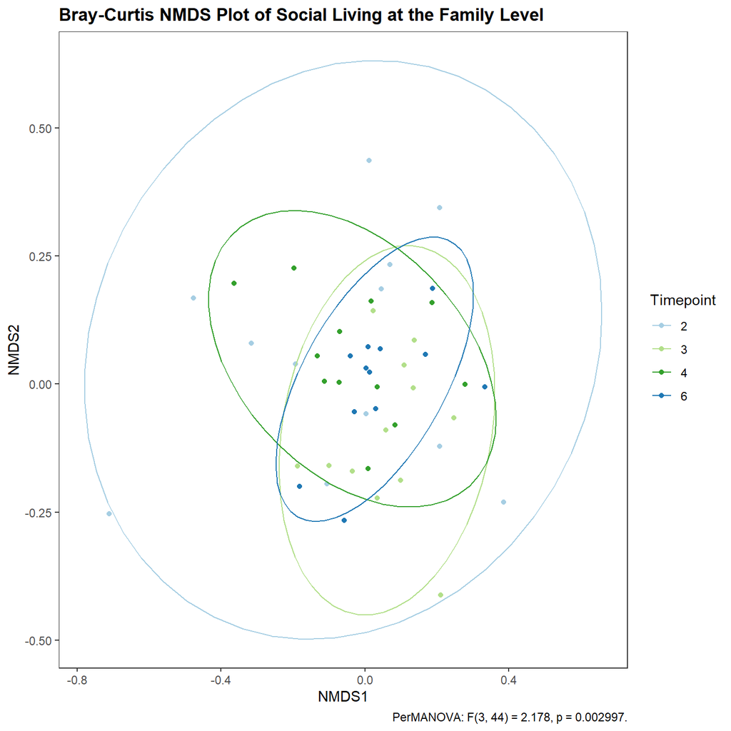

```r
ordination_graph_social_bray_family <- ordination_plot2("bray", "Family") %T>% plot
```

```
## Square root transformation
## Wisconsin double standardization
## *** Best solution was not repeated -- monoMDS stopping criteria:
##     20: stress ratio > sratmax
```

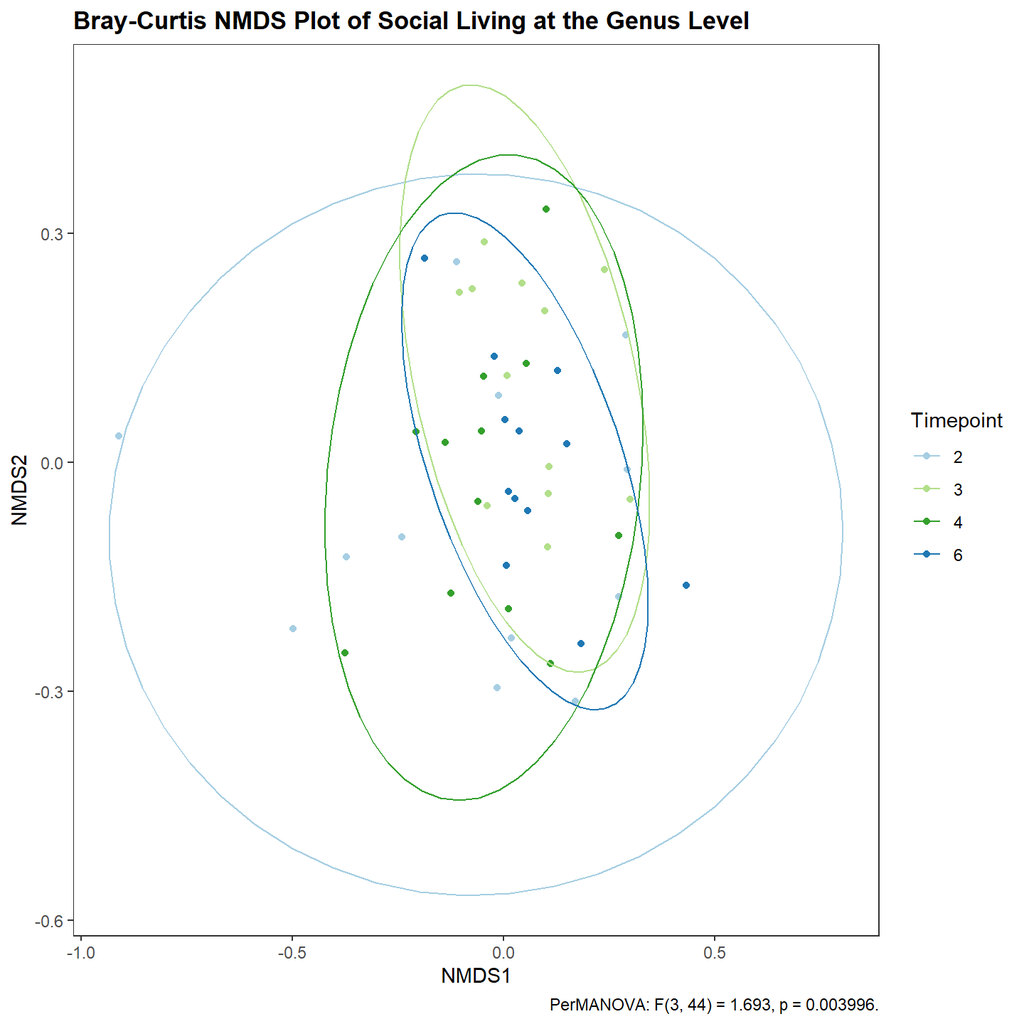

```r
ordination_graph_social_bray_genus <- ordination_plot2("bray", "Genus") %T>% plot
```

Our PERMANOVA analysis revealed a significant effect of social living condition on gut microbiota composition. To assess which timepoints are driving this effect we conducted pairwise comparisons. We conducted this analysis at the family level with weighted UniFrac distances.

**Follow-up Pairwise Comparisons for the Significant Effect of Social Living**

```r
# ------ Weighted Unifrac Matrix ------ #
dist_wunifrac <- phyloseq::distance(ps, method = "wunifrac")

# ------ Run pairwise comparisons ------ #
pairwise_wunifrac <- pairwise.adonis2(dist_wunifrac ~ Timepoint, data = as(sample_data(ps), "data.frame"), strata = "Name")
print(pairwise_wunifrac)
```

```
## $parent_call
## [1] "dist_wunifrac ~ Timepoint , strata = Name , permutations 999"
##
## $`1_vs_2`
##           Df SumOfSqs      R2      F Pr(>F)
## Timepoint  1  0.15723 0.11418 2.8359  0.003 **
## Residual  22  1.21976 0.88582
## Total     23  1.37699 1.00000
## ---
## Signif. codes:  0 '***' 0.001 '**' 0.01 '*' 0.05 '.' 0.1 ' ' 1
##
## $`1_vs_3`
##           Df SumOfSqs      R2      F Pr(>F)
## Timepoint  1  0.09168 0.08697 2.0957  0.005 **
## Residual  22  0.96240 0.91303
## Total     23  1.05407 1.00000
## ---
## Signif. codes:  0 '***' 0.001 '**' 0.01 '*' 0.05 '.' 0.1 ' ' 1
##
## $`1_vs_4`
##           Df SumOfSqs      R2      F Pr(>F)
## Timepoint  1  0.12857 0.11826 2.9508  0.002 **
## Residual  22  0.95856 0.88174
## Total     23  1.08712 1.00000
## ---
## Signif. codes:  0 '***' 0.001 '**' 0.01 '*' 0.05 '.' 0.1 ' ' 1
##
## $`1_vs_6`
##           Df SumOfSqs      R2      F Pr(>F)
## Timepoint  1  0.10353 0.10273 2.4043  0.022 *
## Residual  21  0.90424 0.89727
## Total     22  1.00777 1.00000
## ---
## Signif. codes:  0 '***' 0.001 '**' 0.01 '*' 0.05 '.' 0.1 ' ' 1
##
## $`2_vs_3`
##           Df SumOfSqs      R2      F Pr(>F)
## Timepoint  1  0.12112 0.08564 2.2477  0.014 *
## Residual  24  1.29326 0.91436
## Total     25  1.41438 1.00000
```

[output cut: 26 more lines]

```
##
## $`3_vs_6`
##           Df SumOfSqs      R2     F Pr(>F)
## Timepoint  1  0.04948 0.04817 1.164  0.265
## Residual  23  0.97774 0.95183
## Total     24  1.02722 1.00000
##
## $`4_vs_6`
##           Df SumOfSqs      R2     F Pr(>F)
## Timepoint  1  0.04213 0.04147 0.995  0.193
## Residual  23  0.97390 0.95853
## Total     24  1.01603 1.00000
##
## attr(,"class")
## [1] "pwadstrata" "list"
```

```r
# Create list of timepoint comparisons
comparisons <- c("1_vs_2", "1_vs_3", "1_vs_4", "1_vs_6", "2_vs_3", "2_vs_4", "2_vs_6", "3_vs_4", "3_vs_6", "4_vs_6")

# Create an empty tibble with specific columns for all the values.
stats_wunifrac <- tibble(
  distance_method = character(),
  timepoint1 = character(),
  timepoint2 = character(),
  df1 = numeric(),
  df2 = numeric(),
  R2 = numeric(),
  F.stat = numeric(),
  p = numeric()
)

# Insert values from analysis into the empty tibble
stats_wunifrac<- comparisons %>% map_dfr(
  \(x) stats_wunifrac %>% add_row(
    distance_method = "Weighted uniFrac",
    timepoint1 = substr(x, 1, 1),
    timepoint2 = substr(x, 6, 6),
    df1 = pairwise_wunifrac[[x]]$Df[1],
    df2 = pairwise_wunifrac[[x]]$Df[2],
    R2 = pairwise_wunifrac[[x]]$R2[1],
    F.stat = pairwise_wunifrac[[x]]$F[1],
    p = pairwise_wunifrac[[x]]$`Pr(>F)`[1]
  )
)

View(stats_wunifrac)
```

Regarding the social living conditions, T2 is significantly different from T3 and T4.

Next, to evaluate the specific bacteria that may be driving this significant effect of social living, we again conducted an LEfSe analyss at the family and genus levels. Reported in-text are the family level results. Genus level results are reported in the supplementary files.

Noteably, T1 is significantly different from all timepoints. This is to be expected as it indicates our effect of diet.

##### Figure 3C: LEfSe Tests & Plots for Social Living Effect

*Note that the genus level analysis is presented in the supplmental materials and is not discussed in the main text.*

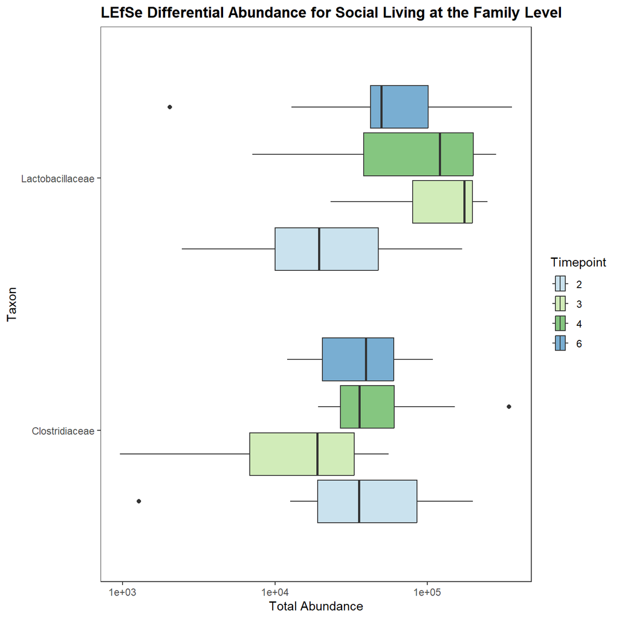

```r
# Differential Bacterial Abundance for Social Living: Timepoints 2, 3, 4, & RSL(T6)
social_palette <- c("#A6CEE3", "#B2DF8A", "#33A02C", "#1F78B4")

#----- FAMILY LEVEL -----#

# Run LEfSe analysis
lefse_social_family <- ps_social %>%
subset_samples(Timepoint %in% c("2", "3", "4", "6")) %>%
run_lefse(
  group = "Timepoint",
  taxa_rank = "Family",
  wilcoxon_cutoff = 0.05,
  kw_cutoff = 0.05,
  lda_cutoff = 3
)

# View results
lefse_social_family_RESULTS <- marker_table(lefse_social_family) %>% as_tibble %>% mutate(Test = "Timepoint")
View(lefse_social_family_RESULTS)

# Graph results
graph_relAbund_Social_family <- lefse_social_family %>%
plot_abundance(group = "Timepoint") +
scale_x_continuous(trans = "log10") +
labs(
  x = "Total Abundance",
  y = "Taxon",
  title = "LEfSe Differential Abundance for Social Living at the Family Level") +
theme(plot.title = element_text(face = "bold"), panel.grid = element_blank()) +
scale_y_discrete(labels = function(x) gsub("_.*", "", x)) +
scale_fill_manual(values = alpha(social_palette, 0.6))
plot(graph_relAbund_Social_family)
```

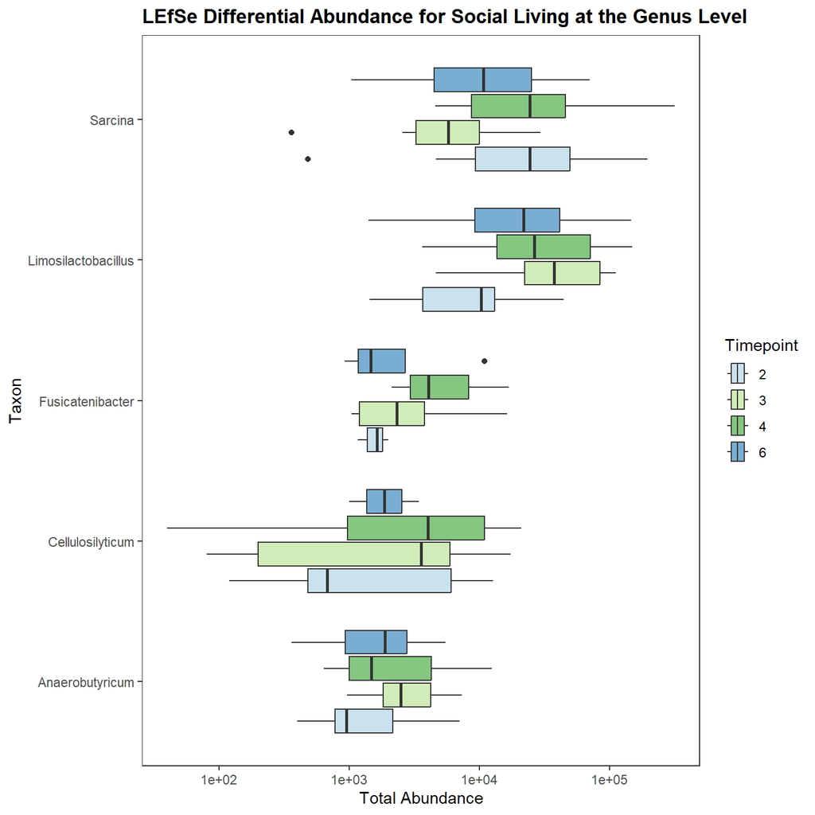

```r
#----- GENUS LEVEL -----#

# Run LEfSe analysis
lefse_social_genus <- ps_social %>%
subset_samples(Timepoint %in% c("2", "3", "4", "6")) %>%
run_lefse(
  group = "Timepoint",
  taxa_rank = "Genus",
  wilcoxon_cutoff = 0.05,
  kw_cutoff = 0.05,
  lda_cutoff = 3
)

# View results
lefse_social_genus_RESULTS <- marker_table(lefse_social_genus) %>% as_tibble %>% mutate(Test = "Timepoint")
View(lefse_social_genus_RESULTS)

# Graph results
graph_relAbund_Social_genus <- lefse_social_genus %>%
plot_abundance(group = "Timepoint") +
scale_x_continuous(trans = "log10") +
labs(
  x = "Total Abundance",
  y = "Taxon",
  title = "LEfSe Differential Abundance for Social Living at the Genus Level"
) +
theme(plot.title = element_text(face = "bold"), panel.grid = element_blank()) +
scale_y_discrete(labels = function(x) gsub("_.*", "", x)) +
scale_fill_manual(values = alpha(social_palette, 0.6))
plot(graph_relAbund_Social_genus)
```

Two bacterial families, Lactobacillaceae and Clostridiaceae, were identified to be significantly changing across timepoints in the LEfSe analysis for *both* the **diet effect and the social living effect.** We look into the trends of these bacteria next.

#### Figure 4: Lactobacillaceae and Clostridaceae appear to be equally modulated by a change in diet and social living condition

**Create dataframe with abundance values**

```r
# Be sure that the required packages are loaded:
library(tidyverse)
library(dplyr)

# Create palette for the following graphs
abund_palette <- c("#E31A1C", "#A6CEE3", "#B2DF8A", "#33A02C", "#1F78B4")

# Create dataframe for the abundance value matrix and for the individual bacteria abundance graphs
data_melt <- select(melt, Timepoint, Sample, Family, Abundance) %>%
  filter(Family != "Other") %>%
  pivot_wider(names_from = Family, values_from = Abundance, names_sep = "_", values_fill = 0)

data_melt <- data_melt[order(data_melt$Timepoint), ]

# strip out the appendices/sample numbers
clean_names = function(row){
  prefix = strsplit(row["Sample"], "\\d")[[1]][1]
  return(prefix)
}

data_melt$Sample = apply(data_melt, 1, clean_names)

View(data_melt)
```

**Create data frames for both bacterial families**

Here we are creating the individual dataframes that are holding the percent abundance values across timepoints for both Lactobacillaceae and Clostridiaceae. We next create the plots to show the percent abundance changes for each bacteria across all timepoints. Lactobacillaceae is first printed, followed by Clostridiaceae. These are the main plots used for Fig. 4A and 4B, respectively.

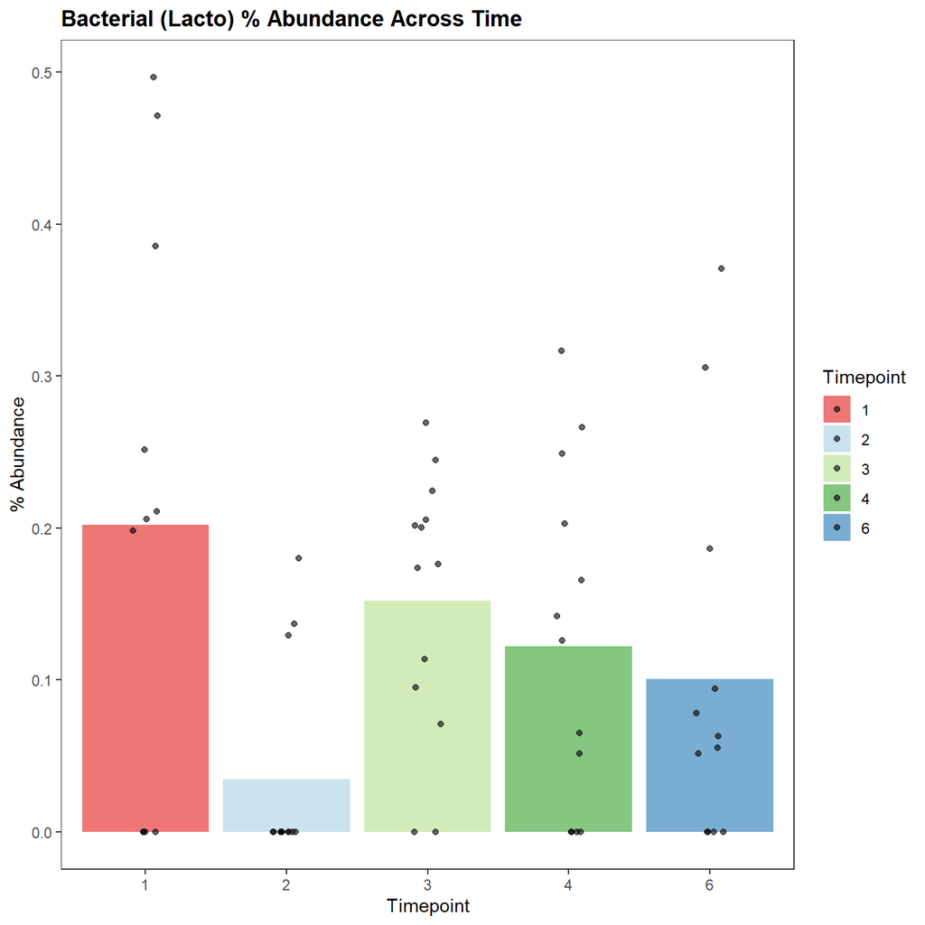

```r
# Create dataframe for Lacto and clsot data
lacto_data <- data_melt %>% select(Timepoint, Sample, Lactobacillaceae)
lacto_data<- lacto_data[order(lacto_data$Sample), ]
View(lacto_data)

# Create data frame specifically for Clost data
clost_data <- data_melt %>% select(Timepoint, Sample, Clostridiaceae)
clost_data<- clost_data[order(clost_data$Sample), ]
View(clost_data)

# ---------- 4A = Main Lactobacillaceae Plot: Abund. Change Over Timepoints ---------- #

# Create plot showing abundance values for Lactobacillaceae across all timepoints
plot_lacto <- ggplot(lacto_data, aes(x = Timepoint, y = Lactobacillaceae, fill = Timepoint)) +
    stat_summary(aes(y = Lactobacillaceae), fun = mean, geom = "bar", alpha = 0.6) +
    scale_fill_manual(values = abund_palette) +
    # stat_compare_means(method = "wilcox.test",position = position_jitter(0.7)) +
    geom_point(aes(y = Lactobacillaceae), position = position_jitter(width = 0.1), alpha = 0.6) +
    theme_bw() +
    theme(plot.title = element_text(face = "bold"), panel.grid = element_blank()) +
    labs(
      title = "Bacterial (Lacto) % Abundance Across Time",
      x = "Timepoint",
      y = "% Abundance"
      )
plot(plot_lacto)
```

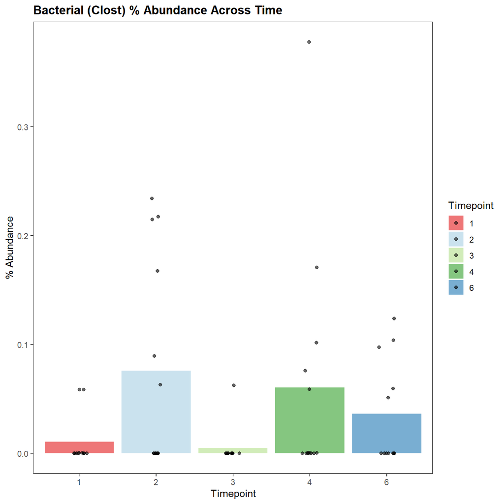

```r
# Note: Significance bars were added after using Adobe Illustrator

# ---------- 4B = Main Clostridiaceae Plot: Abund. Change Over Timepoints ---------- #

# Create plot showing abundance values for Clostridiaceae across all timepoints
plot_clost <- ggplot(clost_data, aes(x = Timepoint, y = Clostridiaceae, fill = Timepoint)) +
    stat_summary(aes(y = Clostridiaceae), fun = mean, geom = "bar", alpha = 0.6) +
    scale_fill_manual(values = abund_palette) +
    geom_point(aes(y = Clostridiaceae), position = position_jitter(width = 0.1), alpha = 0.6) +
    theme_bw() +
    theme(plot.title = element_text(face = "bold"), panel.grid = element_blank()) +
    labs(
      title = "Bacterial (Clost) % Abundance Across Time",
      x = "Timepoint",
      y = "% Abundance"
      )
plot(plot_clost)
```

```r
# Note: Significance bars were added after using Adobe Illustrator
```

We next conducted pairwise comparisons between each timpeoint for each bacteria to see which timepoints differed significantly in percent abundance. However, we first had to filter the data, as some animals did not having samples for all timepoints. Sample exclusion is discussed in the main text.

```r
# Define parameters for each of the comparisons made for the Lactobacillaceae and Clostridiaceae data.
# Different timepoint comparisons will have different animals due to inavailability of samples at different timepoints.
orange = list(name = "1v2-4", excluded_names = c("Popeye", "Quinn"), excluded_timepoints = c(6))
yellow = list(name = "1v6", excluded_names = c("Popeye", "Quinn", "Eli"), excluded_timepoints = c(2, 3, 4))
blue = list(name = "2v3-4", excluded_names = c("No Exclusion"), excluded_timepoints = c(1,6))
green = list(name = "2v-6", excluded_names = c("Eli"), excluded_timepoints = c(1))
comparisons = list(orange, yellow, blue, green)

# data structure to hold results for all comparisons
figure4_data = list(
  lacto = list(name = "Lactobacillaceae", data = lacto_data, filtered = c(), results = c()),
  clost = list(name = "Clostridiaceae", data = clost_data, filtered = c(), results = c())
)
```

**Pairwise comparisons for Figure 4A & 4B**

After filtering and prepping the data non-parametric Wilcoxon signed-rank tests were used to assess significance between the timepoints (for each bacteria).

Note that comparisons of “1v2-4” and “2v3-6” will have repeat pairwise tests (specificialy, comparing timepoints 2, 3, and 4). This is because there are different N values used in each. In “1v2-4”, N = 11, whereas in “2v3-6”, N =13. Thus the comparisons between timepoints 2, 3, and 4 produced from the “1v2-4” comparisons are incomplete. We report the values for the comparisons of timepoints 2, 3, and 4 produced by the “2v3-6” comparisons because the N = 13, which is the full scope of data for those timepoints. Importantly, between these sets of comparisons, the significance values detected for the comparisons between timepoints 2, 3 and 4 do not differ.

```r
# Conduct pairwise comparisons between timepoints to assess significance between timepoints
for(i in seq_along(figure4_data)){
  for(j in seq_along(comparisons)){

    # create the filtered dataset based on the appropriate exclusion criteria
    figure4_data[[i]]$filtered[[j]] = figure4_data[[i]]$data[
      (!(figure4_data[[i]]$data$Timepoint %in% comparisons[[j]]$excluded_timepoints)
      & !(figure4_data[[i]]$data$Sample %in% comparisons[[j]]$excluded_names)),
      ]

    # run the wilcoxon test to compare means on the filtered data
    figure4_data[[i]]$results[[j]] = compare_means(
        formula = reformulate(termlabels = c("Timepoint"), response = figure4_data[[i]]$name), # formula is 'x ~ y', which is abundance value ~ timepoint
        data = figure4_data[[i]]$filtered[[j]],
        method = "wilcox.test",
        p.adjust.method = "BH",
        paired = TRUE
        )
      print(figure4_data[[i]]$results[[j]])
    print(str_glue("Finished calculating wilcox results for Bacteria: {figure4_data[[i]]$name} and Comparison: {comparisons[[j]]$name}"))
  }
}
```

```
## # A tibble: 6 x 8
##   .y.              group1 group2      p p.adj p.format p.signif method
##   <chr>            <chr>  <chr>   <dbl> <dbl> <chr>    <chr>    <chr>
## 1 Lactobacillaceae 1      2      0.0225 0.067 0.022    *        Wilcoxon
## 2 Lactobacillaceae 1      3      0.415  0.5   0.415    ns       Wilcoxon
## 3 Lactobacillaceae 1      4      0.236  0.35  0.236    ns       Wilcoxon
## 4 Lactobacillaceae 2      3      0.0191 0.067 0.019    *        Wilcoxon
## 5 Lactobacillaceae 2      4      0.0440 0.088 0.044    *        Wilcoxon
## 6 Lactobacillaceae 3      4      0.838  0.84  0.838    ns       Wilcoxon
## Finished calculating wilcox results for Bacteria: Lactobacillaceae and Comparison: 1v2-4
## # A tibble: 1 x 8
##   .y.              group1 group2     p p.adj p.format p.signif method
##   <chr>            <chr>  <chr>  <dbl> <dbl> <chr>    <chr>    <chr>
## 1 Lactobacillaceae 1      6      0.141  0.14 0.14     ns       Wilcoxon
## Finished calculating wilcox results for Bacteria: Lactobacillaceae and Comparison: 1v6
## # A tibble: 3 x 8
##   .y.              group1 group2       p p.adj p.format p.signif method
##   <chr>            <chr>  <chr>    <dbl> <dbl> <chr>    <chr>    <chr>
## 1 Lactobacillaceae 2      3      0.00859 0.026 0.0086   **       Wilcoxon
## 2 Lactobacillaceae 2      4      0.0323  0.048 0.0323   *        Wilcoxon
## 3 Lactobacillaceae 3      4      0.410   0.41  0.4101   ns       Wilcoxon
## Finished calculating wilcox results for Bacteria: Lactobacillaceae and Comparison: 2v3-4
## # A tibble: 6 x 8
##   .y.              group1 group2      p p.adj p.format p.signif method
##   <chr>            <chr>  <chr>   <dbl> <dbl> <chr>    <chr>    <chr>
## 1 Lactobacillaceae 2      3      0.0145 0.087 0.014    *        Wilcoxon
## 2 Lactobacillaceae 2      4      0.0440 0.13  0.044    *        Wilcoxon
## 3 Lactobacillaceae 2      6      0.141  0.28  0.141    ns       Wilcoxon
## 4 Lactobacillaceae 3      4      0.505  0.5   0.505    ns       Wilcoxon
## 5 Lactobacillaceae 3      6      0.204  0.31  0.204    ns       Wilcoxon
## 6 Lactobacillaceae 4      6      0.407  0.49  0.407    ns       Wilcoxon
## Finished calculating wilcox results for Bacteria: Lactobacillaceae and Comparison: 2v-6
## # A tibble: 6 x 8
##   .y.            group1 group2      p p.adj p.format p.signif method
##   <chr>          <chr>  <chr>   <dbl> <dbl> <chr>    <chr>    <chr>
## 1 Clostridiaceae 1      2      0.0346  0.11 0.035    *        Wilcoxon
## 2 Clostridiaceae 1      3      1       1    1.000    ns       Wilcoxon
## 3 Clostridiaceae 1      4      0.178   0.21 0.178    ns       Wilcoxon
## 4 Clostridiaceae 2      3      0.0360  0.11 0.036    *        Wilcoxon
## 5 Clostridiaceae 2      4      0.0935  0.15 0.093    ns       Wilcoxon
```

[output cut: 9 more lines]

```
##   <chr>          <chr>  <chr>   <dbl> <dbl> <chr>    <chr>    <chr>
## 1 Clostridiaceae 2      3      0.0360 0.089 0.036    *        Wilcoxon
## 2 Clostridiaceae 2      4      0.447  0.45  0.447    ns       Wilcoxon
## 3 Clostridiaceae 3      4      0.0591 0.089 0.059    ns       Wilcoxon
## Finished calculating wilcox results for Bacteria: Clostridiaceae and Comparison: 2v3-4
## # A tibble: 6 x 8
##   .y.            group1 group2      p p.adj p.format p.signif method
##   <chr>          <chr>  <chr>   <dbl> <dbl> <chr>    <chr>    <chr>
## 1 Clostridiaceae 2      3      0.0591  0.28 0.059    ns       Wilcoxon
## 2 Clostridiaceae 2      4      0.675   0.81 0.675    ns       Wilcoxon
## 3 Clostridiaceae 2      6      0.477   0.72 0.477    ns       Wilcoxon
## 4 Clostridiaceae 3      4      0.100   0.28 0.100    ns       Wilcoxon
## 5 Clostridiaceae 3      6      0.142   0.28 0.142    ns       Wilcoxon
## 6 Clostridiaceae 4      6      0.906   0.91 0.906    ns       Wilcoxon
## Finished calculating wilcox results for Bacteria: Clostridiaceae and Comparison: 2v-6
```

The significant results from these analyses are indicated on Fig. 4A and 4B with significance bars and asterisks (added to figures using Adobe Illustrator).

**Create the Inset Graphs for Figure 4A and 4B**

Next we test to see if the changes in percent abundance from T1 to T2 and T2 to T3 differed significantly in each of the two bacteria. We again applied a Wilcoxon signed-rank test.

**Note**: We have used the *absolute values* of the differences between each timepoint to assess overall magnitude, rather than direction.

```r
# ---------- 4A Inset Lactobacillaceae Plot: Diff. in Abundance Changes ---------- #

# select timepoints and remove 'subject'
filtered_lacto <- lacto_data %>%
  filter(Timepoint %in% c(1, 2, 3) & !(Sample %in% c("Popeye", "Quinn")))

filtered_lacto <- filtered_lacto %>% pivot_wider(
  names_from = Timepoint,
  values_from = Lactobacillaceae
  )

filtered_lacto <- filtered_lacto %>% mutate(
    abso_diffs_T1T2 = abs(filtered_lacto$`1` - filtered_lacto$`2`),
    abso_diffs_T2T3 = abs(filtered_lacto$`2` - filtered_lacto$`3`)
    )

filtered_lacto_diffs <- filtered_lacto %>% select(-`1`, -`2`, -`3`) %>%
  pivot_longer(
  cols = c('abso_diffs_T1T2', 'abso_diffs_T2T3'),
  names_to = "Timepoint",
  values_to = "Absolute_Difference"
  )
View(filtered_lacto_diffs)

# Run wilcoxon test to compare the differences
wilcox_test(filtered_lacto_diffs, Absolute_Difference ~ Timepoint, paired = TRUE) %>% add_significance() %>% print()
```

```
## # A tibble: 1 x 8
##   .y.                 group1          group2             n1    n2 statistic     p p.signif
##   <chr>               <chr>           <chr>           <int> <int>     <dbl> <dbl> <chr>
## 1 Absolute_Difference abso_diffs_T1T2 abso_diffs_T2T3    11    11        32 0.683 ns
```

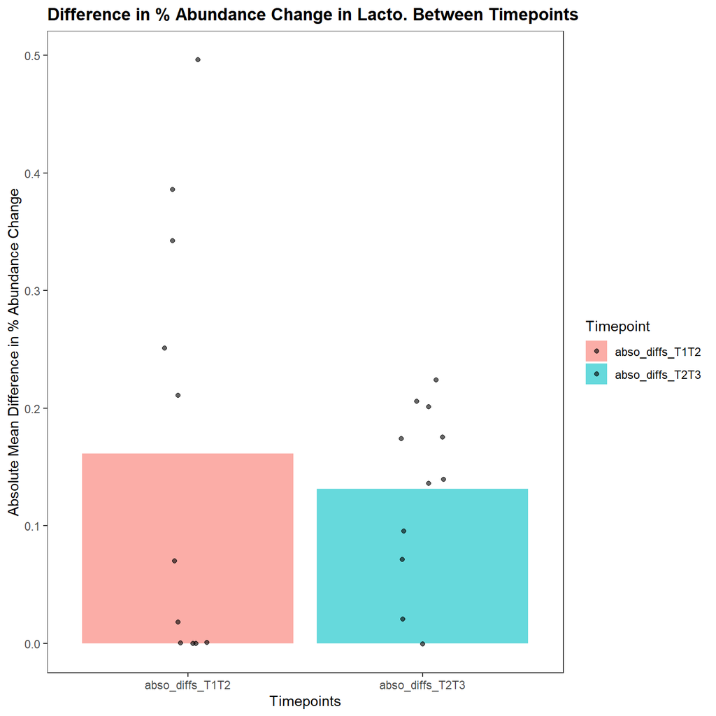

```r
# Plot the difference in abundances from T1 to T2 vs. T2 to T3
plot_lacto2 <- ggplot(filtered_lacto_diffs, aes(x = Timepoint, y = Absolute_Difference, fill = Timepoint)) +
    stat_summary(aes(y = Absolute_Difference), fun = mean, geom = "bar", alpha = 0.6) +
    geom_point(aes(y = Absolute_Difference), position = position_jitter(width = 0.1), alpha = 0.6) +
    theme_bw() +
    theme(plot.title = element_text(face = "bold"), panel.grid = element_blank()) +
    labs(
      title = "Difference in % Abundance Change in Lacto. Between Timepoints",
      x = "Timepoints",
      y = "Absolute Mean Difference in % Abundance Change"
      )

plot(plot_lacto2)
```

```r
# ---------- 4B Inset Clostridiaceae Plot: Diff. in Abundance Changes ---------- #

# select timepoints and remove 'subject'
filtered_clost <- clost_data %>%
  filter(Timepoint %in% c(1, 2, 3) & !(Sample %in% c("Popeye", "Quinn")))

filtered_clost <- filtered_clost %>% pivot_wider(
  names_from = Timepoint,
  values_from = Clostridiaceae
  )

filtered_clost <- filtered_clost %>% mutate(
    abso_diffs_T1T2 = abs(filtered_clost$`1` - filtered_clost$`2`),
    abso_diffs_T2T3 = abs(filtered_clost$`2` - filtered_clost$`3`)
    )

filtered_clost_diffs <- filtered_clost %>% select(-`1`, -`2`, -`3`) %>%
  pivot_longer(
  cols = c('abso_diffs_T1T2', 'abso_diffs_T2T3'),
  names_to = "Timepoint",
  values_to = "Absolute_Difference"
  )
View(filtered_clost_diffs)

# Run wilcoxon test to compare the differences
wilcox_test(filtered_clost_diffs, Absolute_Difference ~ Timepoint, paired = TRUE) %>% add_significance() %>% print()
```

```
## # A tibble: 1 x 8
##   .y.                 group1          group2             n1    n2 statistic     p p.signif
##   <chr>               <chr>           <chr>           <int> <int>     <dbl> <dbl> <chr>
## 1 Absolute_Difference abso_diffs_T1T2 abso_diffs_T2T3    11    11         5 0.423 ns
```

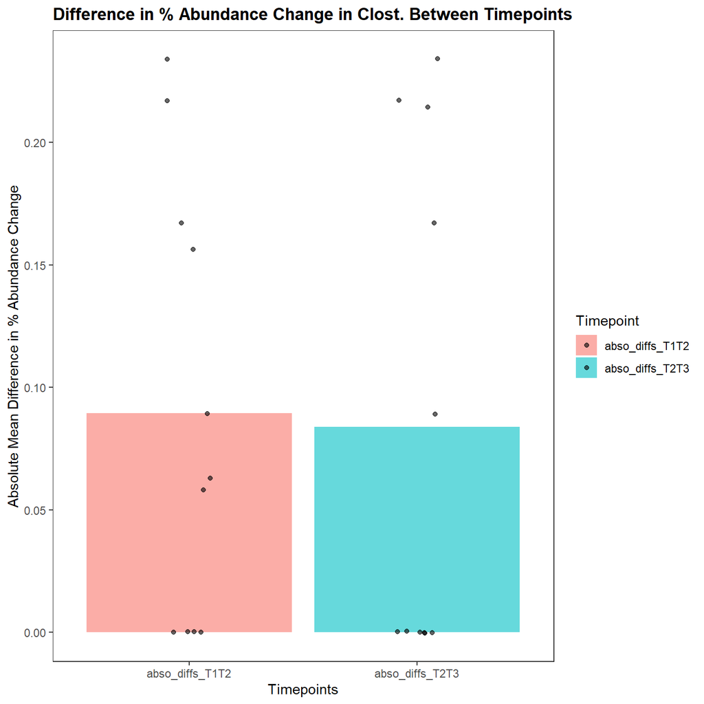

```r
# Plot the difference in abundances from T1 to T2 vs. T2 to T3
plot_clost2 <- ggplot(filtered_clost_diffs, aes(x = Timepoint, y = Absolute_Difference, fill = Timepoint)) +
    stat_summary(aes(y = Absolute_Difference), fun = mean, geom = "bar", alpha = 0.6) +
    geom_point(aes(y = Absolute_Difference), position = position_jitter(width = 0.1), alpha = 0.6) +
    theme_bw() +
    theme(plot.title = element_text(face = "bold"), panel.grid = element_blank()) +
    labs(
      title = "Difference in % Abundance Change in Clost. Between Timepoints",
      x = "Timepoints",
      y = "Absolute Mean Difference in % Abundance Change"
      )
plot(plot_clost2)
```

Importantly, the absolute mean change in percent abundance from T1 to T2 and T2 to T3 in both bacteria was **not** significantly different. This suggests that the changes we see in these bacteria as a result of diet are similar in magnitude to the changes we see in these bacteria as a result of their social living condition.